# CDsampling: An R Package for Constrained D-Optimal Sampling in Paid Research Studies

### Applications in paid research study: $\tt trauma\_data$ example

In the [**CDsampling**](https://CRAN.R-project.org/package=CDsampling) package, `trauma_data` is a dataset of $N=802$ trauma patients from (Chuang-Stein and Agresti 1997), stratified according to the trauma severity at the entry time of the study with $392$ mild and $410$ moderate/severe patients enrolled. The study involved four treatment groups determined by the `dose` level, $x_{i1} = 1$ (`Placebo`), $2$ (`Low dose`), $3$ (`Medium dose`), and $4$ (`High dose`). Combining with `severity` grade ($x_{i2} = 0$ for `mild` or $1$ for `moderate`/`severe`), there are $m=8$ distinct experimental settings with $(x_{i1}, x_{i2}) = (1,0), (2,0), (3,0), (4,0), (1,1), (2,1), (3,1), (4,1)$, respectively. The responses belong to five ordered categories, `Death` ($1$), `Vegetative state` ($2$), `Major disability` ($3$), `Minor disability` ($4$) and `Good` `recovery` ($5$), known as the Glasgow Outcome Scale (Jennett and Bond 1975). Figure 6 shows the distribution of outcomes over `severity` grades and `dose` levels.

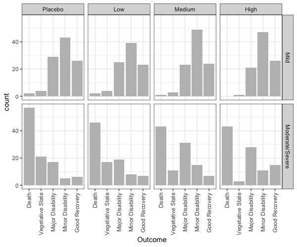

Figure 6: The number of patients from different `dose` levels (Placebo, Low, Medium, and High) and `severity` grades (Mild, Moderate/Severe) groups and their treatment outcomes in `trauma_data` of [**CDsampling**](https://CRAN.R-project.org/package=CDsampling) package.

In this example, we have $m=8$ subgroups, which are combinations of the two covariates categories: `dose` levels and `severity` grades. We aim to enroll $n=600$ patients from the $802$ available patients. The collection of feasible allocations is inherently constrained by the number of patients in different severity grades, defined as
$$S=\{(w_1, \ldots, w_8)^\top \in S_0 \mid
n(w_1+w_2+w_3+w_4) \leq 392, ~~ n(w_5+w_6+w_7+w_8) \leq 410\}.$$
The constraints specify that in the sample, the number of patients with mild symptoms must not exceed $392$ across all dose levels, while those with moderate/severe symptoms must not exceed $410$.

The parameters fitted from the `trauma_data` are
$$\begin{align*}
\boldsymbol\beta &= (\hat\beta_{11}, \hat\beta_{12}, \hat\beta_{13},
\hat\beta_{21}, \hat\beta_{22}, \hat\beta_{23}, \hat\beta_{31},
\hat\beta_{32}, \hat\beta_{33}, \hat\beta_{41}, \hat\beta_{42},
\hat\beta_{43})^\top \\
&= (-4.047, -0.131, 4.214, -2.225, -0.376, 3.519, -0.302,
-0.237, 2.420, 1.386, -0.120, 1.284)^\top.
\end{align*}$$
The model can be written in the following format:
$$\begin{align*}
\log\left(\frac{\pi_{i1}}{\pi_{i2}+\dots+\pi_{i5}}\right) &=
\beta_{11}+\beta_{12}x_{i1}+\beta_{13}x_{i2}\\
\log\left(\frac{\pi_{i1}+\pi_{i2}}{\pi_{i3}+\pi_{i4}+\pi_{i5}}\right)
&= \beta_{21}+\beta_{22}x_{i1}+\beta_{23}x_{i2}\\
\log\left(\frac{\pi_{i1}+\pi_{i2}+\pi_{i3}}{\pi_{i4}+\pi_{i5}}\right)
&= \beta_{31}+\beta_{32}x_{i1}+\beta_{33}x_{i2}\\
\log\left(\frac{\pi_{i1}+\dots+\pi_{i4}}{\pi_{i5}}\right)
&=\beta_{41}+\beta_{42}x_{i1}+\beta_{43}x_{i2}
\end{align*}$$
where $i=1,\dots,8$.

We use the R codes below to define the model matrix and coefficients.

```r
> J=5; p=12; m=8; #response levels; parameters; subgroups

> #coefficients
> beta = c(-4.047, -0.131, 4.214, -2.225, -0.376, 3.519, -0.302, -0.237,  2.420, 1.386,
+ -0.120,  1.284)

> #define design matrix of 8 subgroups
> Xi=rep(0,J*p*m); dim(Xi)=c(J,p,m);
> Xi[,,1] = rbind(c( 1, 1, 0, 0, 0, 0, 0, 0, 0, 0, 0, 0),
+   c( 0, 0, 0, 1, 1, 0, 0, 0, 0, 0, 0, 0), c( 0, 0, 0, 0, 0, 0, 1, 1, 0, 0, 0, 0),
+   c( 0, 0, 0, 0, 0, 0, 0, 0, 0, 1, 1, 0), c( 0, 0, 0, 0, 0, 0, 0, 0, 0, 0, 0, 0))

> Xi[,,2] = rbind(c( 1, 2, 0, 0, 0, 0, 0, 0, 0, 0, 0, 0),
+   c( 0, 0, 0, 1, 2, 0, 0, 0, 0, 0, 0, 0), c( 0, 0, 0, 0, 0, 0, 1, 2, 0, 0, 0, 0),
+   c( 0, 0, 0, 0, 0, 0, 0, 0, 0, 1, 2, 0), c( 0, 0, 0, 0, 0, 0, 0, 0, 0, 0, 0, 0))

> Xi[,,3] = rbind(c( 1, 3, 0, 0, 0, 0, 0, 0, 0, 0, 0, 0),
+   c( 0, 0, 0, 1, 3, 0, 0, 0, 0, 0, 0, 0), c( 0, 0, 0, 0, 0, 0, 1, 3, 0, 0, 0, 0),
+   c( 0, 0, 0, 0, 0, 0, 0, 0, 0, 1, 3, 0), c( 0, 0, 0, 0, 0, 0, 0, 0, 0, 0, 0, 0))

> Xi[,,4] = rbind(c( 1, 4, 0, 0, 0, 0, 0, 0, 0, 0, 0, 0),
+   c( 0, 0, 0, 1, 4, 0, 0, 0, 0, 0, 0, 0), c( 0, 0, 0, 0, 0, 0, 1, 4, 0, 0, 0, 0),
+   c( 0, 0, 0, 0, 0, 0, 0, 0, 0, 1, 4, 0), c( 0, 0, 0, 0, 0, 0, 0, 0, 0, 0, 0, 0))

> Xi[,,5] = rbind(c( 1, 1, 1, 0, 0, 0, 0, 0, 0, 0, 0, 0),
+   c( 0, 0, 0, 1, 1, 1, 0, 0, 0, 0, 0, 0), c( 0, 0, 0, 0, 0, 0, 1, 1, 1, 0, 0, 0),
+   c( 0, 0, 0, 0, 0, 0, 0, 0, 0, 1, 1, 1), c( 0, 0, 0, 0, 0, 0, 0, 0, 0, 0, 0, 0))

> Xi[,,6] = rbind(c( 1, 2, 1, 0, 0, 0, 0, 0, 0, 0, 0, 0),
+   c( 0, 0, 0, 1, 2, 1, 0, 0, 0, 0, 0, 0), c( 0, 0, 0, 0, 0, 0, 1, 2, 1, 0, 0, 0),
+   c( 0, 0, 0, 0, 0, 0, 0, 0, 0, 1, 2, 1), c( 0, 0, 0, 0, 0, 0, 0, 0, 0, 0, 0, 0))

> Xi[,,7] = rbind(c( 1, 3, 1, 0, 0, 0, 0, 0, 0, 0, 0, 0),
+   c( 0, 0, 0, 1, 3, 1, 0, 0, 0, 0, 0, 0), c( 0, 0, 0, 0, 0, 0, 1, 3, 1, 0, 0, 0),
+   c( 0, 0, 0, 0, 0, 0, 0, 0, 0, 1, 3, 1), c( 0, 0, 0, 0, 0, 0, 0, 0, 0, 0, 0, 0))

> Xi[,,8] = rbind(c( 1, 4, 1, 0, 0, 0, 0, 0, 0, 0, 0, 0),
+   c( 0, 0, 0, 1, 4, 1, 0, 0, 0, 0, 0, 0), c( 0, 0, 0, 0, 0, 0, 1, 4, 1, 0, 0, 0),
+   c( 0, 0, 0, 0, 0, 0, 0, 0, 0, 1, 4, 1), c( 0, 0, 0, 0, 0, 0, 0, 0, 0, 0, 0, 0))
```

To define the sample size, the constraints, and the functions of lower and upper boundaries $r_{i1}$ and $r_{i2}$, we may use the following R codes (see Section S3 in the Supplementary Material of (Huang, Tong, and Yang 2025) for details on finding $r_{i1}$ and $r_{i2}$):

```r
> nsample=600 #sample size
> constraint = c(392, 410)  #mild:severe

> #lower bound function in step 3 of constrained liftone
> lower.bound <- function(i, w0){
+   n = 600
+   constraint = c(392,410)
+   if(i <= 4){
+     a.lower <- (sum(w0[5:8])-(constraint[2]/n)*(1-w0[i]))/(sum(w0[5:8]))}
+   else{
+     a.lower <- (sum(w0[1:4])-(constraint[1]/n)*(1-w0[i]))/(sum(w0[1:4]))}
+    a.lower}

> #upper bound function in step 3 of constrained liftone
> upper.bound <- function(i, w0){
+  n = 600
+  constraint = c(392,410)
+  if(i <= 4){
+    b.upper <- ((constraint[1]/n)*(1-w0[i]) - (sum(w0[1:4])-w0[i]))/(1-sum(w0[1:4]))}
+  else{
+    b.upper <- ((constraint[2]/n)*(1-w0[i]) - (sum(w0[5:8])-w0[i]))/(1-sum(w0[5:8]))}
+    b.upper}

> #define constraints
> g.con = matrix(0,nrow=length(constraint)+1+m, ncol=m)
> g.con[2:3,] = matrix(data=c(1,1,1,1,0,0,0,0,0,0,0,0,1,1,1,1), ncol = m, byrow=TRUE)
> g.con[1,] = rep(1, m)
> g.con[4:(length(constraint)+1+m), ] = diag(1, nrow=m)
> g.dir = c("==", "<=","<=", rep(">=",m))
> g.rhs = c(1, ifelse((constraint/nsample<1),constraint/nsample,1), rep(0, m))
```

Then, we may define an optional label of the sampling subgroups that corresponds to each of the $m=8$ subgroups using the following code:

```r
> label=label = c("Placebo-Mild", "Low-Mild", "Medium-Mild", "High-Mild", "Placebo-Severe",
+ "Low-Severe", "Medium-Severe", "High-Severe")
```

We then run the constrained lift-one algorithm to find the constrained D-optimal approximate allocation using `liftone_constrained_MLM()` function and convert the approximate allocation to an exact allocation with `approxtoexact_constrained_func` function.

```r
> set.seed(123)
> approx_design = liftone_constrained_MLM(m=m, p=p, Xi=Xi, J=J, beta=beta,
+ lower.bound=lower.bound, upper.bound=upper.bound, g.con=g.con, g.dir=g.dir,
+ g.rhs=g.rhs, w00=NULL, link='cumulative',  Fi.func=Fi_func_MLM, reltol=1e-5,
+ maxit=500, delta=1e-6, epsilon=1e-8, random=TRUE, nram=3, label=label)

> exact_design = approxtoexact_constrained_func(n=600, w=approx_design$w, m=8,
+ beta=beta, link='cumulative', X=Xi, Fdet_func=Fdet_func_MLM,
+ iset_func=iset_func_trauma, label=label)

> print(exact_design)

Optimal Sampling Results:
================================================================================
Optimal exact allocation:
             Placebo-Mild Low-Mild Medium-Mild High-Mild Placebo-Severe
allocation      155.0        0.0      0.0         100.0     168.0
allocation.real 0.2593       0.0      0.0         0.1667    0.2796
              Low-Severe Medium-Severe High-Severe
allocation      0.0        0.0           177.0
allocation.real 0.0        0.0           0.2944
--------------------------------------------------------------------------------
det.maximum :
1.63163827059162e+23
--------------------------------------------------------------------------------
```

The **allocation** output provides the exact allocation of the sampling across different treatment-severity subgroups, representing the implementable sample sizes for each subgroup. The result is derived by converting the **allocation.real**, which is the D-optimal approximate allocation outcome from `liftone_constrained_MLM()`.

As the `trauma_data` example doesn’t have bounded constraints, to find the constrained uniform sampling allocation, we use `approxtoexact_constrained_func()` with one subject in each stratum or subgroup as the input, that is, the approximate allocation $\mathbf w = (1/600, 1/600, 1/600, 1/600,$ $1/600, 1/600, 1/600, 1/600)$. The corresponding $I$ set function is provided in the [**CDsampling**](https://CRAN.R-project.org/package=CDsampling) package, and it can be easily defined according to other constraints, see Section S4 of Supplementary Material. Note that the determinant provided by `approxtoexact_constrained_func()` for different designs is not comparable, as the criteria `Fdet_func` differs.

```r
> unif_design = approxtoexact_constrained_func(n=600, w=rep(1/600,8), m=8,
+ beta=NULL, link=NULL, X=NULL, Fdet_func=Fdet_func_unif, iset_func=iset_func_trauma)

> print(unif_design)

Optimal Sampling Results:
================================================================================
Optimal exact allocation:
                Placebo-Mild Low-Mild Medium-Mild High-Mild Placebo-Severe Low-Severe
allocation      75.0         75.0     75.0        75.0      75.0           75.0
allocation.real 0.0017       0.0017   0.0017      0.0017    0.0017         0.0017
                Medium-Severe High-Severe
allocation      75.0          75.0
allocation.real 0.0017        0.0017
--------------------------------------------------------------------------------
det.maximum :
1001129150390625
--------------------------------------------------------------------------------
```

## Summary

The current version of [**CDsampling**](https://CRAN.R-project.org/package=CDsampling) implements D-optimal allocations within both paid research sampling and general study frameworks with or without constraints. Its primary objective is to optimize sampling allocations for better model estimation accuracy in the studies. The package includes `F_func_GLM()` and `F_func_MLM()` for the computation of the Fisher information matrix of GLMs and MLMs, respectively. It is noteworthy that standard linear regression models are special GLMs with an identity link function and Gaussian-distributed responses, which is also supported by our package. Theoretical results are summarized in Section 2.2 and Section 2.3 while illustrative examples are provided in Supplementary Section S1.

To find standard or unconstrained D-optimal allocations, our package implements the lift-one algorithm through functions `liftone_GLM()` and `liftone_MLM()`. Paid research studies often impose sampling constraints. To address this, the constrained lift-one algorithm can be applied using functions `liftone_constrained_GLM()` and `liftone_constrained_MLM()`. An example illustrating the difference between the lift-one algorithm and the constrained lift-one algorithm is provided in Supplementary Section S2 while Section 3 presents two application examples from paid research studies.

Future enhancements of the package may aim to incorporate a broader spectrum of optimality criteria, such as A-optimality and E-optimality, as well as some models beyond GLMs and MLMs to expand its applicability.

Agresti, A. 2013. *Categorical Data Analysis*. 3rd ed. Wiley. https://doi.org/10.1007/s00362-015-0733-8.

Atkinson, A. C., A. N. Donev, and R. D. Tobias. 2007. *Optimum Experimental Designs, with SAS*. Oxford University Press. https://doi.org/10.1093/oso/9780199296590.001.0001.

Barcaroli, Giulio. 2014. “SamplingStrata: An R Package for the Optimization of Stratified Sampling.” *Journal of Statistical Software* 61: 1–24. https://doi.org/10.18637/jss.v061.i04.

Bu, X., D. Majumdar, and J. Yang. 2020. “D-Optimal Designs for Multinomial Logistic Models.” *Annals of Statistics* 48 (2): 983–1000. https://doi.org/10.1214/19-AOS1834.

Chuang-Stein, C., and A. Agresti. 1997. “Tutorial in Biostatistics-a Review of Tests for Detecting a Monotone Dose-Response Relationship with Ordinal Response Data.” *Statistics in Medicine* 16: 2599–2618.

Dobson, A. J., and A. G. Barnett. 2018. *An Introduction to Generalized Linear Models*. 4th ed. Chapman & Hall/CRC. https://doi.org/10.1201/9781315182780.

Dousti Mousavi, Niloufar, Hani Aldirawi, and Jie Yang. 2023. “Categorical Data Analysis for High-Dimensional Sparse Gene Expression Data.” *BioTech* 12 (3): 52. https://doi.org/10.3390/biotech12030052.

Fedorov, V. V. 1972. *Theory of Optimal Experiments*. Academic Press.

Fedorov, V. V., and S. L. Leonov. 2014. *Optimal Design for Nonlinear Response Models*. Chapman & Hall/CRC. https://doi.org/10.1201/b15054.

Glonek, G. F. V., and P. McCullagh. 1995. “Multivariate Logistic Models.” *Journal of the Royal Statistical Society, Series B* 57: 533–46. https://www.jstor.org/stable/2346155.

Grömping, Ulrike. 2011. “Optimal Experimental Design with R.” *Journal of Statistical Software* 43: 1–4. https://doi.org/10.18637/jss.v043.b05.

Harman, Radoslav, Lenka Filova, and Maintainer Lenka Filova. 2016. “Package ‘OptimalDesign’.” https://cran.r-project.org/package=OptimalDesign.

Huang, Yifei, Liping Tong, and Jie Yang. 2025. “Constrained d-Optimal Design for Paid Research Study.” *Statistica Sinica*. https://doi.org/10.5705/ss.202022.0414.

Jennett, B., and M. Bond. 1975. “Assessment of Outcome After Severe Brain Damage.” *Lancet* 305: 480–84. https://doi.org/10.1016/S0140-6736(75)92830-5.

Khuri, A. I., B. Mukherjee, B. K. Sinha, and M. Ghosh. 2006. “Design Issues for Generalized Linear Models: A Review.” *Statistical Science* 21: 376–99. https://doi.org/10.1214/088342306000000105.

Kiefer, J. 1974. “General Equivalence Theory for Optimum Designs (Approximate Theory).” *Annals of Statistics* 2: 849–79. https://doi.org/10.1214/aos/1176342810.

Levy, Paul S., and Stanley. Lemeshow. 2008. *Sampling of Populations: Methods and Applications*. 4th ed. Hoboken, N.J: Wiley. https://doi.org/10.1002/9780470374597.

Lohr, S. L. 2019. *Sampling: Design and Analysis*. Chapman; Hall/CRC. https://doi.org/10.1201/9780429298899.

McCullagh, P., and J. Nelder. 1989. *Generalized Linear Models*. 2nd ed. Chapman; Hall/CRC. https://doi.org/10.1007/978-1-4899-3242-6.

Nelder, John Ashworth, and Robert WM Wedderburn. 1972. “Generalized Linear Models.” *Journal of the Royal Statistical Society Series A: Statistics in Society* 135 (3): 370–84. https://doi.org/10.2307/2344614.

Overstall, Antony M., David C. Woods, and Maria Adamou. 2020. “Acebayes: An R Package for Bayesian Optimal Design of Experiments via Approximate Coordinate Exchange.” *Journal of Statistical Software* 95 (13): 1–33. https://doi.org/10.18637/jss.v095.i13.

Overstall, Antony M, David C Woods, Maria Adamou, and Damianos Michaelides. 2018. “Package ‘Acebayes’.” https://cran.r-project.org/package=acebayes.

Pukelsheim, Friedrich. 2006. *Optimal Design of Experiments*. Philadelphia: SIAM. https://doi.org/10.1137/1.9780898719109.

Stufken, J., and M. Yang. 2012. “Optimal Designs for Generalized Linear Models.” In *Design and Analysis of Experiments, Volume 3: Special Designs and Applications*, edited by K. Hinkelmann, 137–64. Wiley. https://doi.org/10.1002/9781118147634.

Tillé, Yves. 2006. *Sampling Algorithms*. Springer. https://doi.org/10.1007/0-387-34240-0.

Tillé, Yves, and Alina Matei. 2016. “Package ‘Sampling’.” *Surv. Sampling. Kasutatud* 23: 2017. https://cran.r-project.org/package=sampling.

Wang, Tianmeng, and Jie Yang. n.d. “Identifying the Most Appropriate Order for Categorical Responses.” *Statistica Sinica* 35: 411–30. https://doi.org/10.25417/uic.25599399.v1.

Wheeler, Bob, and Maintainer Jerome Braun. 2019. “Package ‘AlgDesign’.” *R Proj. Stat. Comput* 1 (0): 1–25. https://cloud.r-project.org/web/packages/AlgDesign/AlgDesign.pdf.

Wickham, Hadley. 2016. *Ggplot2: Elegant Graphics for Data Analysis*. Springer-Verlag New York. https://ggplot2.tidyverse.org.

Wickham, Hadley, Romain François, Lionel Henry, Kirill Müller, and Davis Vaughan. 2023. *Dplyr: A Grammar of Data Manipulation*. https://dplyr.tidyverse.org.

Yang, J., and A. Mandal. 2015. “D-Optimal Factorial Designs Under Generalized Linear Models.” *Communications in Statistics - Simulation and Computation* 44: 2264–77. https://doi.org/10.1080/03610918.2013.815773.

Yang, J., A. Mandal, and D. Majumdar. 2016. “Optimal Designs for $2^k$ Factorial Experiments with Binary Response.” *Statistica Sinica* 26: 385–411. https://doi.org/10.5705/ss.2013.265.

Yang, J., L. Tong, and A. Mandal. 2017. “D-Optimal Designs with Ordered Categorical Data.” *Statistica Sinica* 27: 1879–1902. https://doi.org/10.5705/ss.202016.0210.

Yang, M., and J. Stufken. 2012. “Identifying Locally Optimal Designs for Nonlinear Models: A Simple Extension with Profound Consequences.” *Annals of Statistics* 40: 1665–81. https://doi.org/10.1214/12-AOS992.

Zocchi, S. S., and A. C. Atkinson. 1999. “Optimum Experimental Designs for Multinomial Logistic Models.” *Biometrics* 55: 437–44. https://doi.org/10.1111/j.0006-341X.1999.00437.x.